# Marketing Campaigns

## Make Boolean bool!

```python
marketing['is_retained'].dtype
```

```
dtype('bool')
```

```python
marketing['is_retained'] = marketing['is_retained'].astype('bool')
marketing['is_retained'].dtype
```

```
dtype('bool')
```

## an opportunity for feature engineering ?

### Day of The Week : Analysis Aspect Purposes

### channel code encodes subscribing_channel : Memory Efficiency Purposes

### is_correct_lang: product of two features [ language_displayed + language_preferred] : Analysis Ease Purposes

```python
channels = set(marketing['marketing_channel'])
channels
```

```
{'Email', 'Facebook', 'House Ads', 'Instagram', 'Push', nan}
```

```python
# Mapping for Channels
channel_codes = {}; code = 1
for channel in channels:
    if type(channel) == float: continue  # due to nan
    channel_codes[channel] = code
    code += 1
channel_codes
```

```
{'House Ads': 1, 'Email': 2, 'Facebook': 3, 'Push': 4, 'Instagram': 5}
```

```python
marketing['channel_code'] = marketing['marketing_channel'].map(channel_codes)
marketing.head(1)
```

[output not shown]

```python
import numpy as np
```

```python
marketing['is_correct_lang'] = np.where(marketing['language_displayed'] == marketing['language_preferred'],
                                        True,
                                        False)
```

```python
marketing['date_served'].dtype
```

```
dtype('O')
```

```python
# Convert all dates_types to datetime to leaverage dt accessor.
dates_types = ['date_served', 'date_subscribed', 'date_canceled']
for date_col in dates_types:
    marketing[date_col] = pd.to_datetime(marketing[date_col])
```

```python
# 0-> Monday, ....
marketing['day_served'] = marketing['date_served'].dt.dayofweek
marketing.head(1)
```

|  | Unnamed: 0 | user_id | date_served | marketing_channel | variant | converted | language_displayed | language_preferred | age_group | date_subscribed | date_canceled | subscribing_channel | is_retained | DoW | channel_code | is_correct_lang | day_served |
| --- | --- | --- | --- | --- | --- | --- | --- | --- | --- | --- | --- | --- | --- | --- | --- | --- | --- |
| 0 | 0 | a100000029 | 2018-01-01 | House Ads | personalization | True | English | English | 0-18 years | 2018-01-01 | NaT | House Ads | True | 0.0 | 1.0 | True | 0.0 |

# Daily marketing reach by channel, .groupby()

```python
grouped = marketing.groupby(['date_served'])
grouped
```

```
<pandas.core.groupby.generic.DataFrameGroupBy object at 0x7fe5247548e0>
```

```python
daily_users = grouped.agg( {'user_id': ['nunique']}) # count() in you are not interested on unique users
print(type(daily_users))
daily_users.head(3)
```

```
<class 'pandas.core.frame.DataFrame'>
```

| date_served | user_id nunique |
| --- | --- |
| 2018-01-01 | 362 |
| 2018-01-02 | 374 |
| 2018-01-03 | 348 |

## Visualizing daily marketing reach

```python
import matplotlib.pyplot as plt
```

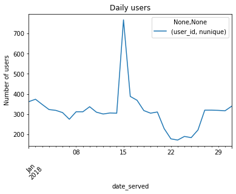

```python
daily_users.plot()

plt.title('Daily users')
plt.ylabel('Number of users')
plt.xticks(rotation=45)

plt.show()
```

# CAPTER2: Common marketing metrics

## Conversion rate = Number of people who convert / Total number of people we marketed to

```python
NO_subscribers = marketing[ marketing['converted'] == True]['user_id'].nunique()
NO_subscribers
```

```
1030
```

```python
total = marketing['user_id'].nunique()
total
```

```
7309
```

```python
conv_rate = NO_subscribers/total
print(round(conv_rate*100, 2),'%')
```

```
14.09 %
```

## Retention rate = Number of people who remain subscribed / Total number of people who converted

```python
NO_retaines = marketing[ marketing['is_retained'] == True]['user_id'].nunique()
NO_retaines
```

```
6967
```

```python
retention = NO_retaines/NO_subscribers
print(round(retention*100, 2), '%')
```

```
676.41 %
```

## Cutomer Segmentation

Calculate Retention Rate for each subscribing_channel  
pandas easy way .. groupby()

```python
retained_subset = marketing[marketing['is_retained'] == True]
grouped_retained = retained_subset.groupby(['subscribing_channel']).agg({'user_id': ['nunique']})
grouped_retained
```

| subscribing_channel | user_id nunique |
| --- | --- |
| Email | 141 |
| Facebook | 152 |
| House Ads | 173 |
| Instagram | 158 |
| Push | 54 |

```python
converted_subset = marketing[marketing['converted'] == True]
grouped_subscribers = converted_subset.groupby(['subscribing_channel']).agg({'user_id': ['nunique']})
grouped_subscribers
```

| subscribing_channel | user_id nunique |
| --- | --- |
| Email | 161 |
| Facebook | 221 |
| House Ads | 298 |
| Instagram | 232 |
| Push | 77 |

```python
channel_retention_rate = (grouped_retained / grouped_subscribers)*100
channel_retention_rate
```

| subscribing_channel | user_id nunique |
| --- | --- |
| Email | 87.577640 |
| Facebook | 68.778281 |
| House Ads | 58.053691 |
| Instagram | 68.103448 |
| Push | 70.129870 |

## Plotting Campaign Results

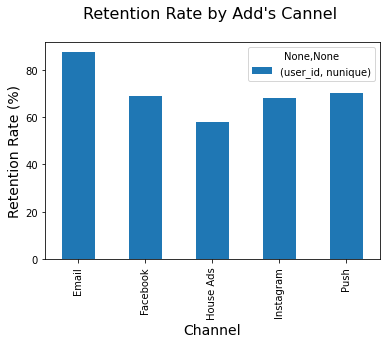

```python
channel_retention_rate.plot(kind='bar')

plt.title("Retention Rate by Add's Cannel \n", size=16)
plt.xlabel("Channel", size=14)
plt.ylabel("Retention Rate (%)", size=14)
plt.show()
```

## Calculating subscriber quality

```python
retained_subset_date_groupped = retained_subset.groupby(['date_subscribed'])
```

```python
r = retained_subset_date_groupped.agg({'user_id': ['nunique']})
```

```python
marketing_date_grouped = marketing.groupby(['date_subscribed'])
marketing_date_grouped
```

```
<pandas.core.groupby.generic.DataFrameGroupBy object at 0x7fe522c3cfa0>
```

```python
m = marketing_date_grouped.agg({'user_id': ['nunique']})
```

```python
daily_retention_rate = r/m
```

```python
daily_retention_rate_df = pd.DataFrame(daily_retention_rate.reset_index())
daily_retention_rate_df.columns = ['date_subscribed','retention_rate']
daily_retention_rate_df
```

|  | date_subscribed | retention_rate |
| --- | --- | --- |
| 0 | 2018-01-01 | 0.777778 |
| 1 | 2018-01-02 | 0.702703 |
| 2 | 2018-01-03 | 0.729730 |
| 3 | 2018-01-04 | 0.500000 |
| 4 | 2018-01-05 | 0.575000 |
| 5 | 2018-01-06 | 0.756757 |
| 6 | 2018-01-07 | 0.526316 |
| 7 | 2018-01-08 | 0.638889 |
| 8 | 2018-01-09 | 0.675000 |
| 9 | 2018-01-10 | 0.682927 |
| 10 | 2018-01-11 | 0.615385 |
| 11 | 2018-01-12 | 0.391304 |
| 12 | 2018-01-13 | 0.500000 |
| 13 | 2018-01-14 | 0.615385 |
| 14 | 2018-01-15 | 0.714286 |
| 15 | 2018-01-16 | 0.701923 |
| 16 | 2018-01-17 | 0.616279 |
| 17 | 2018-01-18 | 0.733333 |
| 18 | 2018-01-19 | 0.684211 |
| 19 | 2018-01-20 | 0.809524 |
| 20 | 2018-01-21 | 0.761905 |
| 21 | 2018-01-22 | 0.772727 |
| 22 | 2018-01-23 | 0.714286 |
| 23 | 2018-01-24 | 0.652174 |
| 24 | 2018-01-25 | 0.565217 |
| 25 | 2018-01-26 | 0.800000 |
| 26 | 2018-01-27 | 0.571429 |
| 27 | 2018-01-28 | 0.666667 |
| 28 | 2018-01-29 | 0.750000 |
| 29 | 2018-01-30 | 0.714286 |
| 30 | 2018-01-31 | 0.666667 |

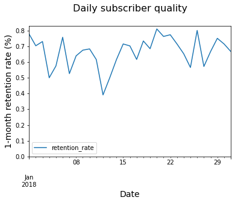

```python
# Create a line chart using the daily_retention DataFrame
daily_retention_rate_df.plot('date_subscribed', 'retention_rate')

plt.title('Daily subscriber quality\n', size = 16)
plt.ylabel('1-month retention rate (%)', size = 14)
plt.xlabel('Date', size = 14)
# Set the y-axis to begin at 0
plt.ylim(0)

plt.show()
```

```python
marketing_nested_grouped = marketing.groupby(['date_served', 'language_preferred'])
date_lang_marketing = marketing_nested_grouped.agg({'user_id': ['count']})
date_lang_marketing.head(4)
```

| date_served | language_preferred | user_id count |
| --- | --- | --- |
| 2018-01-01 | Arabic | 4 |
|  | English | 355 |
|  | German | 5 |
|  | Spanish | 11 |

### Unstacking after groupby by MultiPle Columns

```python
date_lang_marketing_df = pd.DataFrame(date_lang_marketing.unstack(level=1))
date_lang_marketing_df.head()
```

| language_preferred date_served | user_id count Arabic | user_id count English | user_id count German | user_id count Spanish |
| --- | --- | --- | --- | --- |
| 2018-01-01 | 4.0 | 355.0 | 5.0 | 11.0 |
| 2018-01-02 | 4.0 | 397.0 | 6.0 | 10.0 |
| 2018-01-03 | 3.0 | 374.0 | 3.0 | 8.0 |
| 2018-01-04 | 2.0 | 318.0 | 2.0 | 14.0 |
| 2018-01-05 | 1.0 | 314.0 | 2.0 | 14.0 |

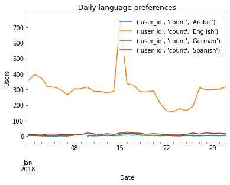

```python
# Plotting preferred language over time
date_lang_marketing_df.plot()  # by Default it will plot for each columns except the 1st, it is the x axis

plt.title('Daily language preferences')
plt.xlabel('Date')
plt.ylabel('Users')
plt.legend(loc = 'upper right',
           labels = date_lang_marketing_df.columns.values)
plt.show()
```

### Creating grouped bar charts

```python
lang_age_grouped = marketing.groupby(['language_preferred', 'age_group'])
lang_age = lang_age_grouped.agg({'user_id': ['count']})
lang_age.head()
```

| language_preferred | age_group | user_id count |
| --- | --- | --- |
| Arabic | 0-18 years | 19 |
|  | 19-24 years | 26 |
|  | 24-30 years | 19 |
|  | 30-36 years | 19 |
|  | 36-45 years | 19 |

```python
lang_age_df = pd.DataFrame(lang_age.unstack(level=1))
lang_age_df
```

| age_group language_preferred | user_id count 0-18 years | user_id count 19-24 years | user_id count 24-30 years | user_id count 30-36 years | user_id count 36-45 years | user_id count 45-55 years | user_id count 55+ years |
| --- | --- | --- | --- | --- | --- | --- | --- |
| Arabic | 19 | 26 | 19 | 19 | 19 | 21 | 22 |
| English | 1421 | 1560 | 1442 | 1251 | 1260 | 1240 | 1101 |
| German | 31 | 29 | 35 | 16 | 19 | 25 | 12 |
| Spanish | 68 | 67 | 72 | 69 | 55 | 67 | 52 |

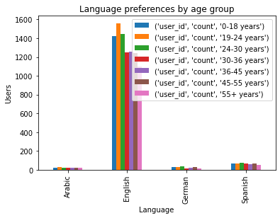

```python
lang_age_df.plot(kind='bar')

plt.title('Language preferences by age group')
plt.xlabel('Language')
plt.ylabel('Users')
plt.legend(loc = 'upper right', labels = lang_age_df.columns.values)

plt.show()
```

# CHAPTER3: Functions to automate common marketing analysis

```python
def retention_rate(dataframe, column_names):
    # Group by column_names and calculate retention
    retained = dataframe[dataframe['is_retained'] == True].groupby(column_names)['user_id'].nunique()
    # Group by column_names and calculate conversion
    converted = dataframe[dataframe['converted'] == True].groupby(column_names)['user_id'].nunique()
    retention_rate = retained/converted
    return retention_rate
```

```python
def conversion_rate(dataframe, column_names):
    # Total number of converted users
    column_conv = dataframe[dataframe['converted'] == True].groupby(column_names)['user_id'].nunique()
    # Total number users
    column_total = dataframe.groupby(column_names)['user_id'].nunique()
    # Conversion rate
    conversion_rate = column_conv/column_total
    # Fill missing values with 0
    conversion_rate = conversion_rate.fillna(0)
    return conversion_rate
```

```python
def plotting_ret(dataframe):
    for column in dataframe:
        plt.plot(dataframe.index, dataframe[column])
        plt.title('Daily ' + column + ' retention rate\n',size = 16)
        plt.ylabel('Retention rate (%)', size = 14)
        plt.xlabel('Date', size = 14)
        plt.show()
        plt.clf()
```

```python
def plotting_conv(dataframe):
    for col in dataframe:
        # Plot column by dataframe's index
        plt.plot(dataframe.index, dataframe[col])
        plt.title('Daily ' + str(col) + ' conversion rate\n',
                  size = 16)
        plt.ylabel('Conversion rate', size = 14)
        plt.xlabel('Date', size = 14)
        # Show plot
        plt.show()
        plt.clf()
```

## Retention rate by channel

```python
daily_retention = retention_rate(marketing,['date_subscribed','subscribing_channel'])
daily_retention_df = pd.DataFrame(daily_retention.unstack(level=1))
daily_retention_df.head(2)
```

| subscribing_channel date_subscribed | Email | Facebook | House Ads | Instagram | Push |
| --- | --- | --- | --- | --- | --- |
| 2018-01-01 | 1.00 | 0.875 | 0.687500 | 0.750 | 1.0 |
| 2018-01-02 | 0.75 | 1.000 | 0.588235 | 0.625 | 1.0 |

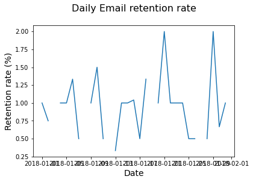

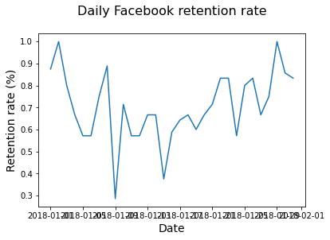

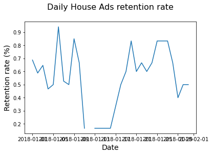

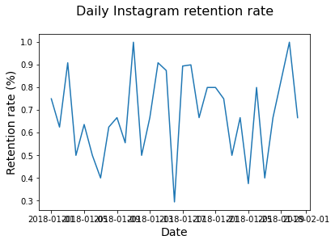

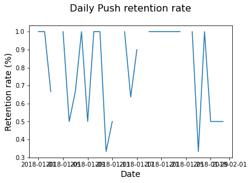

```python
plotting_ret(daily_retention_df)
```

## conversion rate by age_group over The Month

```python
# Calculate conversion rate by age_group
age_group_conv = conversion_rate(marketing, ['date_served', 'age_group'])

# Unstack and create a DataFrame
age_group_df = pd.DataFrame(age_group_conv.unstack(level=1))
age_group_df.head(2)
```

| age_group date_served | 0-18 years | 19-24 years | 24-30 years | 30-36 years | 36-45 years | 45-55 years | 55+ years |
| --- | --- | --- | --- | --- | --- | --- | --- |
| 2018-01-01 | 0.155172 | 0.196721 | 0.105263 | 0.040816 | 0.042553 | 0.022222 | 0.086957 |
| 2018-01-02 | 0.180328 | 0.164384 | 0.114754 | 0.040000 | 0.043478 | 0.043478 | 0.024390 |

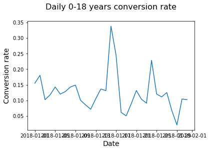

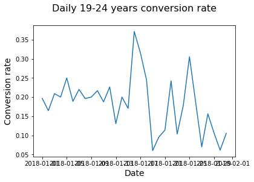

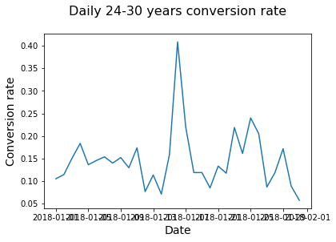

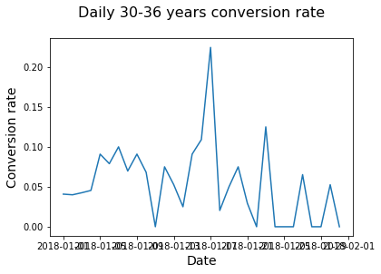

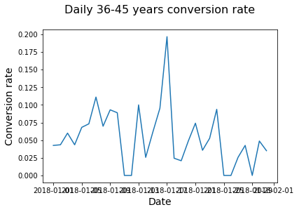

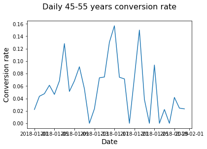

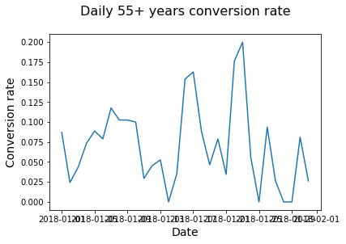

```python
plotting_conv(age_group_df)
```

## Identifying Inconsistencies

### KEEP YOUR EYES ON HOUSE ADs

```python
daily_conv_channel_grouped = conversion_rate(marketing, ['date_served', 'marketing_channel'])
daily_conv_channel_grouped
```

```
date_served  marketing_channel
2018-01-01   Email                1.000000
             Facebook             0.117647
             House Ads            0.084656
             Instagram            0.106667
             Push                 0.083333
                                    ...
2018-01-31   Email                1.000000
             Facebook             0.078947
             House Ads            0.038217
             Instagram            0.041096
             Push                 0.052632
Name: user_id, Length: 155, dtype: float64
```

```python
daily_conv_channel = pd.DataFrame(daily_conv_channel_grouped.unstack(level = 1))
daily_conv_channel.head(2)
```

| marketing_channel date_served | Email | Facebook | House Ads | Instagram | Push |
| --- | --- | --- | --- | --- | --- |
| 2018-01-01 | 1.0 | 0.117647 | 0.084656 | 0.106667 | 0.083333 |
| 2018-01-02 | 1.0 | 0.098361 | 0.077982 | 0.129032 | 0.055556 |

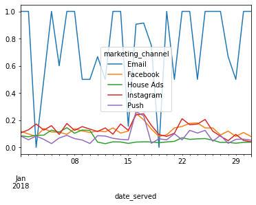

```python
daily_conv_channel.plot()
```

### Look: A sudden decrease in conversion rate due to HOUSE ADs on January 11!

## Add day of week column to marketing

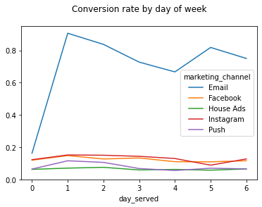

```python
# Calculate conversion rate by day of week
DoW_conversion = conversion_rate(marketing, ['day_served', 'marketing_channel'])
DoW_conversion_df = pd.DataFrame(DoW_conversion.unstack(level=1))

# Plot conversion rate by day of week
DoW_conversion_df.plot()
plt.title('Conversion rate by day of week\n')
plt.ylim(0)
plt.show()
```

```python
house_ads = marketing[marketing['marketing_channel'] == 'House Ads']
house_ads.head(2)
```

|  | Unnamed: 0 | user_id | date_served | marketing_channel | variant | converted | language_displayed | language_preferred | age_group | date_subscribed | date_canceled | subscribing_channel | is_retained | DoW | channel_code | is_correct_lang | day_served |
| --- | --- | --- | --- | --- | --- | --- | --- | --- | --- | --- | --- | --- | --- | --- | --- | --- | --- |
| 0 | 0 | a100000029 | 2018-01-01 | House Ads | personalization | True | English | English | 0-18 years | 2018-01-01 | NaT | House Ads | True | 0.0 | 1.0 | True | 0.0 |
| 1 | 1 | a100000030 | 2018-01-01 | House Ads | personalization | True | English | English | 19-24 years | 2018-01-01 | NaT | House Ads | True | 0.0 | 1.0 | True | 0.0 |

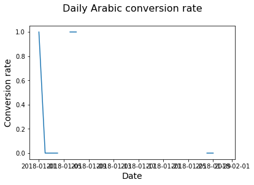

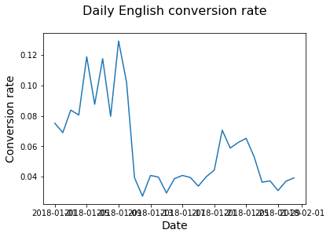

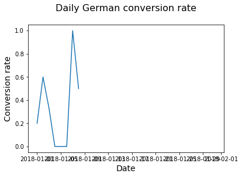

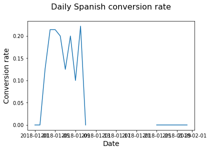

```python
conv_lang_channel = conversion_rate(house_ads, ['date_served', 'language_displayed'])
conv_lang_df = pd.DataFrame(conv_lang_channel.unstack(level=1))
plotting_conv(conv_lang_df)
```

### look: As you can see, the English conversion rate drops around the 11th, and there do not appear to be ads served in other languages for a two week period. You will investigate further

```python
language_check_grouped = house_ads.groupby(by=['date_served', 'is_correct_lang'])['user_id'].count()
language_check_df = pd.DataFrame(language_check_grouped.unstack(level=1)).fillna(0)
language_check_df.head(30)
```

| is_correct_lang date_served | False | True |
| --- | --- | --- |
| 2018-01-01 | 2.0 | 189.0 |
| 2018-01-02 | 3.0 | 247.0 |
| 2018-01-03 | 0.0 | 220.0 |
| 2018-01-04 | 0.0 | 168.0 |
| 2018-01-05 | 0.0 | 160.0 |
| 2018-01-06 | 1.0 | 151.0 |
| 2018-01-07 | 2.0 | 130.0 |
| 2018-01-08 | 0.0 | 154.0 |
| 2018-01-09 | 0.0 | 157.0 |
| 2018-01-10 | 0.0 | 170.0 |
| 2018-01-11 | 20.0 | 135.0 |
| 2018-01-12 | 18.0 | 130.0 |
| 2018-01-13 | 26.0 | 122.0 |
| 2018-01-14 | 20.0 | 131.0 |
| 2018-01-15 | 16.0 | 192.0 |
| 2018-01-16 | 28.0 | 127.0 |
| 2018-01-17 | 21.0 | 127.0 |
| 2018-01-18 | 31.0 | 121.0 |
| 2018-01-19 | 22.0 | 127.0 |
| 2018-01-20 | 28.0 | 124.0 |
| 2018-01-21 | 14.0 | 100.0 |
| 2018-01-22 | 13.0 | 72.0 |
| 2018-01-23 | 16.0 | 69.0 |
| 2018-01-24 | 13.0 | 83.0 |
| 2018-01-25 | 19.0 | 74.0 |
| 2018-01-26 | 24.0 | 92.0 |
| 2018-01-27 | 18.0 | 149.0 |
| 2018-01-28 | 28.0 | 136.0 |
| 2018-01-29 | 24.0 | 142.0 |
| 2018-01-30 | 23.0 | 145.0 |

## New Column: what percentage of users were being served ads in the right language

```python
# Divide the count where language is correct by the row sum
language_check_df['pct'] = language_check_df[True]/language_check_df.sum(axis=1)
```

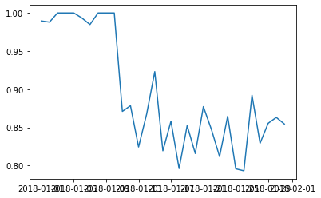

```python
# Plot and show your results
plt.plot(language_check_df.index.values, language_check_df['pct'])
plt.show()
```

## SUCCESS in Identifing Inconsistency

### You have shown that house ads have been underperforming due to serving all ads in English rather than each user's preferred language

# Resolving Inconsistencies

## Interesting Thing: Know how many subscribers they lost as a result of this bug.

- before the language bug arose: All is Well, What if it is contiued that way ?  
  you will index non-English language conversion rates against English conversion rates in the time period before the language bug arose

```python
# Calculate pre-error conversion rate
house_ads_before_bug = house_ads[house_ads['date_served'] < '2018-01-11']
house_ads_before_bug.head(2)
```

|  | Unnamed: 0 | user_id | date_served | marketing_channel | variant | converted | language_displayed | language_preferred | age_group | date_subscribed | date_canceled | subscribing_channel | is_retained | DoW | channel_code | is_correct_lang | day_served |
| --- | --- | --- | --- | --- | --- | --- | --- | --- | --- | --- | --- | --- | --- | --- | --- | --- | --- |
| 0 | 0 | a100000029 | 2018-01-01 | House Ads | personalization | True | English | English | 0-18 years | 2018-01-01 | NaT | House Ads | True | 0.0 | 1.0 | True | 0.0 |
| 1 | 1 | a100000030 | 2018-01-01 | House Ads | personalization | True | English | English | 19-24 years | 2018-01-01 | NaT | House Ads | True | 0.0 | 1.0 | True | 0.0 |

```python
lang_conv_grouped = conversion_rate(house_ads_before_bug, ['language_displayed'])
lang_conv_grouped
```

```
language_displayed
Arabic     0.500000
English    0.099093
German     0.444444
Spanish    0.166667
Name: user_id, dtype: float64
```

```python
# Index other language conversion rate against English
spanish_index = lang_conv_grouped['Spanish']/lang_conv_grouped['English']
arabic_index  = lang_conv_grouped['Arabic'] /lang_conv_grouped['English']
german_index  = lang_conv_grouped['German'] /lang_conv_grouped['English']
```

```python
print("Spanish index:", spanish_index)
print("Arabic index:" , arabic_index)
print("German index:" , german_index)
```

```
Spanish index: 1.681924882629108
Arabic index: 5.045774647887324
German index: 4.485133020344287
```

## Analyzing user preferences

- how many users prefer each language by day ?,
- how many users prefer each language by day Convert ?

```python
converted = house_ads.groupby(by=['date_served', 'language_preferred']).agg({'user_id':'nunique','converted':'sum'})
converted.head(2)
```

| date_served | language_preferred | user_id | converted |
| --- | --- | --- | --- |
| 2018-01-01 | Arabic | 2 | 2 |
|  | English | 171 | 13 |

```python
converted_df = pd.DataFrame(converted.unstack(level=1))
converted_df.head(3)
```

| language_preferred date_served | user_id Arabic | user_id English | user_id German | user_id Spanish | converted Arabic | converted English | converted German | converted Spanish |
| --- | --- | --- | --- | --- | --- | --- | --- | --- |
| 2018-01-01 | 2.0 | 171.0 | 5.0 | 11.0 | 2.0 | 13.0 | 1.0 | 0.0 |
| 2018-01-02 | 3.0 | 200.0 | 5.0 | 10.0 | 0.0 | 14.0 | 3.0 | 0.0 |
| 2018-01-03 | 2.0 | 179.0 | 3.0 | 8.0 | 0.0 | 15.0 | 1.0 | 1.0 |

## The Buggy Subset DataFrame

## Assessing bug impact

### How many Subs you loss ?

```python
# Create English conversion rate column for affected period
converted_df['english_conv_rate'] = converted_df.loc['2018-01-11':'2018-01-31'][('converted','English')]
converted_df
```

| language_preferred date_served | user_id Arabic | user_id English | user_id German | user_id Spanish | converted Arabic | converted English | converted German | converted Spanish | english_conv_rate |
| --- | --- | --- | --- | --- | --- | --- | --- | --- | --- |
| 2018-01-01 | 2.0 | 171.0 | 5.0 | 11.0 | 2.0 | 13.0 | 1.0 | 0.0 | NaN |
| 2018-01-02 | 3.0 | 200.0 | 5.0 | 10.0 | 0.0 | 14.0 | 3.0 | 0.0 | NaN |
| 2018-01-03 | 2.0 | 179.0 | 3.0 | 8.0 | 0.0 | 15.0 | 1.0 | 1.0 | NaN |
| 2018-01-04 | 2.0 | 149.0 | 2.0 | 14.0 | 0.0 | 12.0 | 0.0 | 3.0 | NaN |
| 2018-01-05 | NaN | 143.0 | 1.0 | 14.0 | NaN | 17.0 | 0.0 | 3.0 | NaN |
| 2018-01-06 | 3.0 | 136.0 | 2.0 | 11.0 | 3.0 | 12.0 | 0.0 | 2.0 | NaN |
| 2018-01-07 | 2.0 | 117.0 | 2.0 | 10.0 | 2.0 | 14.0 | 2.0 | 1.0 | NaN |
| 2018-01-08 | NaN | 138.0 | 6.0 | 10.0 | NaN | 11.0 | 3.0 | 2.0 | NaN |
| 2018-01-09 | NaN | 147.0 | NaN | 10.0 | NaN | 19.0 | NaN | 1.0 | NaN |
| 2018-01-10 | NaN | 147.0 | 4.0 | 18.0 | NaN | 15.0 | 2.0 | 4.0 | NaN |
| 2018-01-11 | 7.0 | 133.0 | 2.0 | 13.0 | 0.0 | 6.0 | 0.0 | 0.0 | 6.0 |
| 2018-01-12 | 3.0 | 129.0 | 4.0 | 11.0 | 0.0 | 3.0 | 0.0 | 1.0 | 3.0 |
| 2018-01-13 | 6.0 | 121.0 | 5.0 | 16.0 | 0.0 | 5.0 | 1.0 | 0.0 | 5.0 |
| 2018-01-14 | 5.0 | 131.0 | 3.0 | 12.0 | 0.0 | 6.0 | 0.0 | 0.0 | 6.0 |
| 2018-01-15 | 2.0 | 189.0 | 4.0 | 10.0 | 0.0 | 6.0 | 0.0 | 0.0 | 6.0 |
| 2018-01-16 | 7.0 | 127.0 | 4.0 | 17.0 | 0.0 | 6.0 | 0.0 | 0.0 | 6.0 |
| 2018-01-17 | 2.0 | 126.0 | 3.0 | 16.0 | 0.0 | 2.0 | 0.0 | 4.0 | 2.0 |
| 2018-01-18 | 7.0 | 121.0 | 6.0 | 18.0 | 0.0 | 5.0 | 1.0 | 0.0 | 5.0 |
| 2018-01-19 | 5.0 | 126.0 | 5.0 | 12.0 | 1.0 | 4.0 | 0.0 | 0.0 | 4.0 |
| 2018-01-20 | 6.0 | 124.0 | 6.0 | 14.0 | 1.0 | 4.0 | 1.0 | 0.0 | 4.0 |
| 2018-01-21 | 1.0 | 99.0 | 4.0 | 9.0 | 0.0 | 5.0 | 0.0 | 0.0 | 5.0 |
| 2018-01-22 | 2.0 | 72.0 | 3.0 | 8.0 | 1.0 | 4.0 | 1.0 | 0.0 | 4.0 |
| 2018-01-23 | 3.0 | 69.0 | 4.0 | 9.0 | 0.0 | 5.0 | 0.0 | 0.0 | 5.0 |
| 2018-01-24 | 2.0 | 83.0 | 3.0 | 8.0 | 0.0 | 6.0 | 0.0 | 0.0 | 6.0 |
| 2018-01-25 | 3.0 | 75.0 | 4.0 | 11.0 | 0.0 | 4.0 | 2.0 | 0.0 | 4.0 |
| 2018-01-26 | 6.0 | 89.0 | 3.0 | 16.0 | 0.0 | 4.0 | 0.0 | 2.0 | 4.0 |
| 2018-01-27 | 3.0 | 148.0 | 3.0 | 12.0 | 1.0 | 4.0 | 0.0 | 1.0 | 4.0 |
| 2018-01-28 | 5.0 | 134.0 | 3.0 | 21.0 | 0.0 | 4.0 | 0.0 | 2.0 | 4.0 |
| 2018-01-29 | 7.0 | 138.0 | 4.0 | 15.0 | 2.0 | 3.0 | 0.0 | 0.0 | 3.0 |
| 2018-01-30 | 4.0 | 139.0 | 3.0 | 18.0 | 0.0 | 4.0 | 0.0 | 2.0 | 4.0 |
| 2018-01-31 | 7.0 | 130.0 | 4.0 | 16.0 | 1.0 | 4.0 | 0.0 | 1.0 | 4.0 |

```python
# Create expected conversion rates for each language
converted_df['expected_spanish_rate'] = converted_df['english_conv_rate']*spanish_index
converted_df['expected_arabic_rate']  = converted_df['english_conv_rate']*arabic_index
converted_df['expected_german_rate']  = converted_df['english_conv_rate']*german_index
# converted_df
```

```python
# Multiply number of users by the expected conversion rate
converted_df['expected_spanish_conv'] = converted_df['expected_spanish_rate']/100*converted_df[('user_id','Spanish')]
converted_df['expected_arabic_conv' ] = converted_df['expected_arabic_rate' ]/100*converted_df[('user_id','Arabic' )]
converted_df['expected_german_conv' ] = converted_df['expected_german_rate' ]/100*converted_df[('user_id','German' )]
converted_df
```

| language_preferred date_served | user_id Arabic | user_id English | user_id German | user_id Spanish | converted Arabic | converted English | converted German | converted Spanish | english_conv_rate | expected_spanish_rate | expected_arabic_rate | expected_german_rate | expected_spanish_conv | expected_arabic_conv | expected_german_conv |
| --- | --- | --- | --- | --- | --- | --- | --- | --- | --- | --- | --- | --- | --- | --- | --- |
| 2018-01-01 | 2.0 | 171.0 | 5.0 | 11.0 | 2.0 | 13.0 | 1.0 | 0.0 | NaN | NaN | NaN | NaN | NaN | NaN | NaN |
| 2018-01-02 | 3.0 | 200.0 | 5.0 | 10.0 | 0.0 | 14.0 | 3.0 | 0.0 | NaN | NaN | NaN | NaN | NaN | NaN | NaN |
| 2018-01-03 | 2.0 | 179.0 | 3.0 | 8.0 | 0.0 | 15.0 | 1.0 | 1.0 | NaN | NaN | NaN | NaN | NaN | NaN | NaN |
| 2018-01-04 | 2.0 | 149.0 | 2.0 | 14.0 | 0.0 | 12.0 | 0.0 | 3.0 | NaN | NaN | NaN | NaN | NaN | NaN | NaN |
| 2018-01-05 | NaN | 143.0 | 1.0 | 14.0 | NaN | 17.0 | 0.0 | 3.0 | NaN | NaN | NaN | NaN | NaN | NaN | NaN |
| 2018-01-06 | 3.0 | 136.0 | 2.0 | 11.0 | 3.0 | 12.0 | 0.0 | 2.0 | NaN | NaN | NaN | NaN | NaN | NaN | NaN |
| 2018-01-07 | 2.0 | 117.0 | 2.0 | 10.0 | 2.0 | 14.0 | 2.0 | 1.0 | NaN | NaN | NaN | NaN | NaN | NaN | NaN |
| 2018-01-08 | NaN | 138.0 | 6.0 | 10.0 | NaN | 11.0 | 3.0 | 2.0 | NaN | NaN | NaN | NaN | NaN | NaN | NaN |
| 2018-01-09 | NaN | 147.0 | NaN | 10.0 | NaN | 19.0 | NaN | 1.0 | NaN | NaN | NaN | NaN | NaN | NaN | NaN |
| 2018-01-10 | NaN | 147.0 | 4.0 | 18.0 | NaN | 15.0 | 2.0 | 4.0 | NaN | NaN | NaN | NaN | NaN | NaN | NaN |
| 2018-01-11 | 7.0 | 133.0 | 2.0 | 13.0 | 0.0 | 6.0 | 0.0 | 0.0 | 6.0 | 10.091549 | 30.274648 | 26.910798 | 1.311901 | 2.119225 | 0.538216 |
| 2018-01-12 | 3.0 | 129.0 | 4.0 | 11.0 | 0.0 | 3.0 | 0.0 | 1.0 | 3.0 | 5.045775 | 15.137324 | 13.455399 | 0.555035 | 0.454120 | 0.538216 |
| 2018-01-13 | 6.0 | 121.0 | 5.0 | 16.0 | 0.0 | 5.0 | 1.0 | 0.0 | 5.0 | 8.409624 | 25.228873 | 22.425665 | 1.345540 | 1.513732 | 1.121283 |
| 2018-01-14 | 5.0 | 131.0 | 3.0 | 12.0 | 0.0 | 6.0 | 0.0 | 0.0 | 6.0 | 10.091549 | 30.274648 | 26.910798 | 1.210986 | 1.513732 | 0.807324 |
| 2018-01-15 | 2.0 | 189.0 | 4.0 | 10.0 | 0.0 | 6.0 | 0.0 | 0.0 | 6.0 | 10.091549 | 30.274648 | 26.910798 | 1.009155 | 0.605493 | 1.076432 |
| 2018-01-16 | 7.0 | 127.0 | 4.0 | 17.0 | 0.0 | 6.0 | 0.0 | 0.0 | 6.0 | 10.091549 | 30.274648 | 26.910798 | 1.715563 | 2.119225 | 1.076432 |
| 2018-01-17 | 2.0 | 126.0 | 3.0 | 16.0 | 0.0 | 2.0 | 0.0 | 4.0 | 2.0 | 3.363850 | 10.091549 | 8.970266 | 0.538216 | 0.201831 | 0.269108 |
| 2018-01-18 | 7.0 | 121.0 | 6.0 | 18.0 | 0.0 | 5.0 | 1.0 | 0.0 | 5.0 | 8.409624 | 25.228873 | 22.425665 | 1.513732 | 1.766021 | 1.345540 |
| 2018-01-19 | 5.0 | 126.0 | 5.0 | 12.0 | 1.0 | 4.0 | 0.0 | 0.0 | 4.0 | 6.727700 | 20.183099 | 17.940532 | 0.807324 | 1.009155 | 0.897027 |
| 2018-01-20 | 6.0 | 124.0 | 6.0 | 14.0 | 1.0 | 4.0 | 1.0 | 0.0 | 4.0 | 6.727700 | 20.183099 | 17.940532 | 0.941878 | 1.210986 | 1.076432 |
| 2018-01-21 | 1.0 | 99.0 | 4.0 | 9.0 | 0.0 | 5.0 | 0.0 | 0.0 | 5.0 | 8.409624 | 25.228873 | 22.425665 | 0.756866 | 0.252289 | 0.897027 |
| 2018-01-22 | 2.0 | 72.0 | 3.0 | 8.0 | 1.0 | 4.0 | 1.0 | 0.0 | 4.0 | 6.727700 | 20.183099 | 17.940532 | 0.538216 | 0.403662 | 0.538216 |
| 2018-01-23 | 3.0 | 69.0 | 4.0 | 9.0 | 0.0 | 5.0 | 0.0 | 0.0 | 5.0 | 8.409624 | 25.228873 | 22.425665 | 0.756866 | 0.756866 | 0.897027 |
| 2018-01-24 | 2.0 | 83.0 | 3.0 | 8.0 | 0.0 | 6.0 | 0.0 | 0.0 | 6.0 | 10.091549 | 30.274648 | 26.910798 | 0.807324 | 0.605493 | 0.807324 |
| 2018-01-25 | 3.0 | 75.0 | 4.0 | 11.0 | 0.0 | 4.0 | 2.0 | 0.0 | 4.0 | 6.727700 | 20.183099 | 17.940532 | 0.740047 | 0.605493 | 0.717621 |
| 2018-01-26 | 6.0 | 89.0 | 3.0 | 16.0 | 0.0 | 4.0 | 0.0 | 2.0 | 4.0 | 6.727700 | 20.183099 | 17.940532 | 1.076432 | 1.210986 | 0.538216 |
| 2018-01-27 | 3.0 | 148.0 | 3.0 | 12.0 | 1.0 | 4.0 | 0.0 | 1.0 | 4.0 | 6.727700 | 20.183099 | 17.940532 | 0.807324 | 0.605493 | 0.538216 |
| 2018-01-28 | 5.0 | 134.0 | 3.0 | 21.0 | 0.0 | 4.0 | 0.0 | 2.0 | 4.0 | 6.727700 | 20.183099 | 17.940532 | 1.412817 | 1.009155 | 0.538216 |
| 2018-01-29 | 7.0 | 138.0 | 4.0 | 15.0 | 2.0 | 3.0 | 0.0 | 0.0 | 3.0 | 5.045775 | 15.137324 | 13.455399 | 0.756866 | 1.059613 | 0.538216 |
| 2018-01-30 | 4.0 | 139.0 | 3.0 | 18.0 | 0.0 | 4.0 | 0.0 | 2.0 | 4.0 | 6.727700 | 20.183099 | 17.940532 | 1.210986 | 0.807324 | 0.538216 |
| 2018-01-31 | 7.0 | 130.0 | 4.0 | 16.0 | 1.0 | 4.0 | 0.0 | 1.0 | 4.0 | 6.727700 | 20.183099 | 17.940532 | 1.076432 | 1.412817 | 0.717621 |

```python
#slice only the relevant dates
sliced_converted_df = converted_df.loc['2018-01-11':'2018-01-31']
```

```python
# Sum expected subscribers for each language
expected_subs = sliced_converted_df['expected_spanish_conv'].sum() + sliced_converted_df['expected_arabic_conv'].sum() + sliced_converted_df['expected_german_conv'].sum()
# Calculate how many subscribers we actually got
actual_subs = sliced_converted_df[('converted','Spanish')].sum() + sliced_converted_df[('converted','Arabic')].sum() + sliced_converted_df[('converted','German')].sum()
# Subtract how many subscribers we got despite the bug
lost_subs = expected_subs - actual_subs
lost_subs
```

```
32.14414319248826
```

### Great job! 32 subscribers may not seem like many, but for a small company this can be vitally important, especially when expanding to new markets.

# CHAPTER4: Personalization A/B Testing

## The email portion of this campaign was actually run as an A/B test.

- Half the emails sent out were generic upsells to product
- other half contained personalized messaging around the users’ usage of the site.

## Conversion rate as our key metrics for this test

it is highly important that we evaluate whether or not conversion was higher in the personalization treatment compared with the control.

## Check Allocation is relatively even

```python
# Subset the DataFrame
email = marketing[marketing['marketing_channel']=='Email']
email.head(2)
```

|  | Unnamed: 0 | user_id | date_served | marketing_channel | variant | converted | language_displayed | language_preferred | age_group | date_subscribed | date_canceled | subscribing_channel | is_retained | DoW | channel_code | is_correct_lang | day_served |
| --- | --- | --- | --- | --- | --- | --- | --- | --- | --- | --- | --- | --- | --- | --- | --- | --- | --- |
| 354 | 354 | a100000526 | 2018-01-01 | Email | personalization | True | Arabic | Arabic | 0-18 years | 2018-01-01 | NaT | Email | True | 0.0 | 2.0 | True | 0.0 |
| 358 | 358 | a100000530 | 2018-01-05 | Email | personalization | True | Arabic | Arabic | 19-24 years | 2018-01-05 | NaT | Email | True | 4.0 | 2.0 | True | 4.0 |

```python
# Group the email DataFrame by variant
alloc = email.groupby(by=['variant'])['user_id'].nunique()
alloc
```

```
variant
control            270
personalization    284
Name: user_id, dtype: int64
```

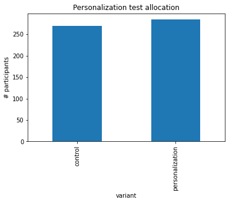

```python
# Plot a bar chart of the test allocation
alloc.plot(kind='bar')
plt.title('Personalization test allocation')
plt.ylabel('# participants')
plt.show()
```

## Critical -> Generate a Data Frame such each user is in one Variant set

```python
# Group marketing by user_id and variant
subscribers = email.groupby(['user_id',
                             'variant'])['converted'].max()
subscribers
```

```
user_id     variant
a100000526  personalization     True
a100000530  personalization     True
a100000534  personalization    False
a100000538  personalization     True
a100000542  personalization     True
                               ...
a100007288  control             True
a100007289  control             True
a100007290  control             True
a100007291  control             True
a100007293  control             True
Name: converted, Length: 554, dtype: bool
```

```python
subscribers_df = pd.DataFrame(subscribers.unstack(level=1))
subscribers_df.head()
```

| variant user_id | control | personalization |
| --- | --- | --- |
| a100000526 | NaN | True |
| a100000530 | NaN | True |
| a100000534 | NaN | False |
| a100000538 | NaN | True |
| a100000542 | NaN | True |

```python
# Drop missing values from the control column
control = subscribers_df['control'].dropna()
# Drop missing values from the personalization column
personalization = subscribers_df['personalization'].dropna()
```

```python
print('Control conversion rate:', np.mean(control))
print('Personalization conversion rate:', np.mean(personalization))
```

```
Control conversion rate: 0.2814814814814815
Personalization conversion rate: 0.3908450704225352
```

### there's a large lift, but are your results statistically significant?

## Calculating lift & significance testing

### lift = ( Treatment conversion rate - control conversion rate ) / control conversion rate

```python
# consumes two pandas series each series consists of bool | NaN values
# return Conversion Rate [mean in this case]
def lift(a,b):
    # Calcuate the mean of a and b
    a_mean = np.mean(a)
    b_mean = np.mean(b)

    # Calculate the lift using a_mean and b_mean
    lift = (b_mean-a_mean)/a_mean

    return str(round(lift*100, 2)) + '%'

# Print lift() with control and personalization as inputs
print(lift(control, personalization))
```

```
38.85%
```

## Evaluating statistical significance

statistical significance is vital to understanding whether a test showed a positive result by chance or if it is reflective of a true difference between the variants.

```python
from scipy import stats
stats.ttest_ind(control, personalization)
```

```
Ttest_indResult(statistic=-2.7343299447505074, pvalue=0.006451487844694175)
```

Amazing job! The personalization results are highly statistically significant

## whether that holds up across all demographics ?

treatment will not affect all people uniformly!

```python
# Generic Function avoid repetitive work
# consumes a String column name
# produces
def ab_segmentation(segment):
  for subsegment in np.unique(marketing[segment]):
      print(subsegment)

      # Limit marketing to email and subsegment
      email = marketing[(marketing['marketing_channel'] == 'Email') & (marketing[segment] == subsegment)]

      subscribers = email.groupby(['user_id', 'variant'])['converted'].max()
      subscribers = pd.DataFrame(subscribers.unstack(level=1))
      control = subscribers['control'].dropna()
      personalization = subscribers['personalization'].dropna()

      print('lift:',        lift(control, personalization))
      print('t-statistic:', stats.ttest_ind(control, personalization), '\n\n')
```

```python
ab_segmentation('language_displayed')
```

```
Arabic
lift: 50.0%
t-statistic: Ttest_indResult(statistic=-0.5773502691896255, pvalue=0.5795840000000001)


English
lift: 39.0%
t-statistic: Ttest_indResult(statistic=-2.2183598646203166, pvalue=0.026991701290720815)


German
lift: -1.62%
t-statistic: Ttest_indResult(statistic=0.1910083418078718, pvalue=0.8494394170062678)


Spanish
lift: 166.67%
t-statistic: Ttest_indResult(statistic=-2.3570226039551585, pvalue=0.040156718110477524)
```

#### works well at English, and Spanish

```python
ab_segmentation('age_group')
```

```
0-18 years
lift: 121.4%
t-statistic: Ttest_indResult(statistic=-2.966044912142211, pvalue=0.0038724494391297226)


19-24 years
lift: 106.24%
t-statistic: Ttest_indResult(statistic=-3.03179438478667, pvalue=0.0030623836114689134)


24-30 years
lift: 161.19%
t-statistic: Ttest_indResult(statistic=-3.861539544326876, pvalue=0.00018743381094867337)


30-36 years
lift: -100.0%
t-statistic: Ttest_indResult(statistic=3.1859064644147996, pvalue=0.0023238487431765137)


36-45 years
lift: -85.23%
t-statistic: Ttest_indResult(statistic=2.4317901279318503, pvalue=0.01797568600978829)


45-55 years
lift: -72.22%
t-statistic: Ttest_indResult(statistic=2.065499127317933, pvalue=0.043062339688201196)


55+ years
lift: -100.0%
t-statistic: Ttest_indResult(statistic=3.3265654564203397, pvalue=0.0016358623456360435)
```

#### personalization was extremely effective for younger groups but less effective than the control for older groups

##### One explanation might be that younger users understand how their data might be used online and think personalization is cool because it gives them more insight into themselves while older people might feel that this is a violation of their privacy.